# Apriori Algorithm - Grocery Store Dataset

Data Science Analysis

2025-09-10

# Introduction

This analysis demonstrates the Apriori algorithm for association rule mining using the Grocery Store Dataset. The Apriori algorithm is one of the most popular algorithms for discovering frequent itemsets and generating association rules from transactional data.

## Objectives

- Implement the Apriori algorithm for association rule mining
- Perform exploratory data analysis on grocery store transactions
- Generate and analyze association rules
- Visualize rule quality metrics
- Evaluate algorithm performance

# Dataset Overview

The Grocery Store Dataset contains transaction data from a grocery store, where each transaction represents a basket of items purchased together. This type of data is ideal for association rule mining to discover patterns in customer purchasing behavior.

```r
# Load required packages
library(arules)      # For Apriori algorithm
library(arulesViz)   # For visualization
library(ggplot2)     # For plotting
library(dplyr)       # For data manipulation
library(gridExtra)   # For arranging multiple plots
library(RColorBrewer) # For color palettes

# Set seed for reproducibility
set.seed(16)
```

```r
# Load the transaction data (preprocess to remove quotes)
raw_data <- readLines("Grocery-Store-Dataset/GroceryStoreDataSet.csv")
clean_data <- gsub('"', '', raw_data)  # Remove quotes
writeLines(clean_data, "temp_transactions.csv")

transactions <- read.transactions("temp_transactions.csv",
                                 format = "basket", sep = ",", rm.duplicates = TRUE)
file.remove("temp_transactions.csv")  # Clean up temporary file
```

```
## [1] TRUE
```

```r
# Display basic information
cat("Number of transactions:", nrow(transactions), "\n")
```

```
## Number of transactions: 20
```

```r
cat("Number of items:", ncol(transactions), "\n")
```

```
## Number of items: 11
```

```r
# Summary of the dataset
summary(transactions)
```

```
## transactions as itemMatrix in sparse format with
##  20 rows (elements/itemsets/transactions) and
##  11 columns (items) and a density of 0.3
##
## most frequent items:
##      BREAD     COFFEE    BISCUIT        TEA CORNFLAKES    (Other)
##         13          8          7          7          6         25
##
## element (itemset/transaction) length distribution:
## sizes
##  2  3  4
##  1 12  7
##
##    Min. 1st Qu.  Median    Mean 3rd Qu.    Max.
##     2.0     3.0     3.0     3.3     4.0     4.0
##
## includes extended item information - examples:
##      labels
## 1   BISCUIT
## 2 BOURNVITA
## 3     BREAD
```

# Exploratory Data Analysis

## Item Frequency Analysis

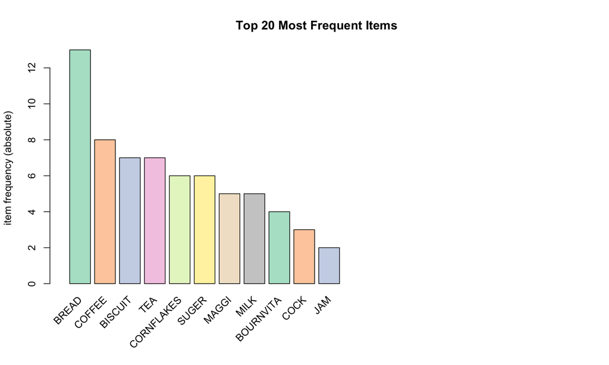

```r
# Item frequency plot (absolute)
itemFrequencyPlot(transactions, topN = 20, type = "absolute",
                  col = brewer.pal(8, "Pastel2"), main = "Top 20 Most Frequent Items")
```

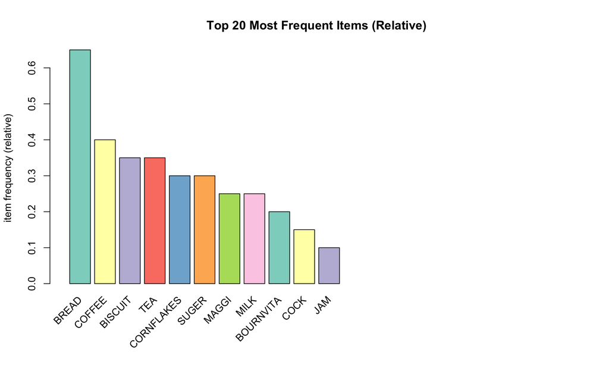

```r
# Item frequency plot (relative)
itemFrequencyPlot(transactions, topN = 20, type = "relative",
                  col = brewer.pal(8, "Set3"), main = "Top 20 Most Frequent Items (Relative)")
```